# Statistiek I - Lab session X

J.F.P. (Richard) Scholtens (s2956586)

Generated on: Fri Apr 20 15:31:13 2018

# 1 Exercise 1

```r
download.file('http://www.let.rug.nl/wieling/Statistiek-I/dat.rda','dat.rda')
load('dat.rda',verbose=T)
```

```
## Loading objects:
##   dat
```

```r
str(dat)
```

```
## 'data.frame':    315 obs. of  18 variables:
##  $ participant         : int  1 2 3 4 5 6 7 8 9 10 ...
##  $ year                : num  2017 2017 2017 2017 2017 ...
##  $ study               : Factor w/ 4 levels "CIS","IS","LING",..: 3 3 3 1 3 3 3 3 3 2 ...
##  $ edu_level           : Factor w/ 3 levels "HAVO","VWO","HBO": 2 NA 2 3 1 2 2 2 2 2 ...
##  $ gender              : Factor w/ 2 levels "F","M": 1 2 2 1 1 1 1 1 1 2 ...
##  $ hand                : Factor w/ 2 levels "R","L": 1 1 1 1 1 1 1 1 1 1 ...
##  $ instrument          : Factor w/ 2 levels "Y","N": 1 2 1 2 2 1 2 2 1 1 ...
##  $ bl_edu              : Factor w/ 2 levels "Y","N": 2 2 2 2 2 2 2 1 2 2 ...
##  $ l1cnt               : num  1 1 1 1 1 1 1 1 1 1 ...
##  $ l2cnt               : num  3 1 2 1 2 3 1 3 1 2 ...
##  $ age_listening       : num  11 11 9 10 11 11 11 9 6 7 ...
##  $ age_reading         : num  10 11 9 10 11 11 11 9 11 7 ...
##  $ age_speaking        : num  10 11 9 10 11 11 12 10 11 7 ...
##  $ age_writing         : num  11 13 9 10 12 11 12 10 11 7 ...
##  $ accent_strength_self: num  8 3 5 7 9 6 4 4 5 4 ...
##  $ english_grade       : num  6 7 8 7 7 8 7 8 6 8 ...
##  $ english_score_self  : num  4 9.5 8.25 7.25 6.75 7.75 7.5 7.75 6.5 9 ...
##  $ english_score       : num  4.31 6.42 8.17 6.99 6.12 ...
```

```r
dmgrade <- dat$english_grade - mean(dat$english_grade)

admgrade <- abs(dat$english_grade)
admgrade <- abs(dat$english_grade - mean(dat$english_grade))

dat$dmgrade <- NULL

mean(admgrade)
```

```
## [1] 0.7006581
```

```r
sd(dat$english_grade)
```

```
## [1] 0.848302
```

# 2 Exercise 2

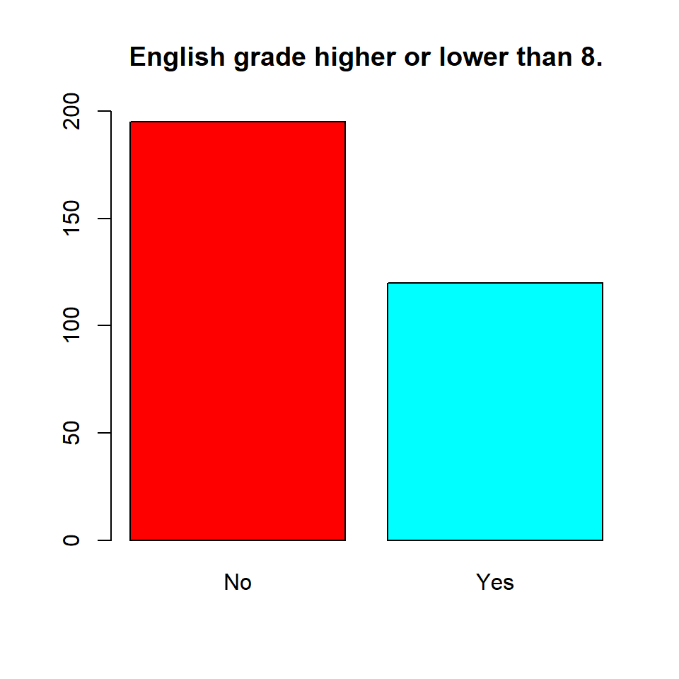

```r
dat$english8 = "Yes"
dat[dat$english_grade < 8,]$english8 <- "No"
dat$english8 <- as.factor(dat$english8)
barplot(table(dat$english8), col=rainbow(2), main="English grade higher or lower than 8.", ylim=c(0,200))
```

# 3 Excercise 3

```r
dat2 <- dat[dat$english8 == "Yes",]
save(dat2, file='dat2.rda')
str(dat2)
```

```
## 'data.frame':    120 obs. of  19 variables:
##  $ participant         : int  3 6 8 10 12 15 17 18 19 22 ...
##  $ year                : num  2017 2017 2017 2017 2017 ...
##  $ study               : Factor w/ 4 levels "CIS","IS","LING",..: 3 3 3 2 4 4 3 2 3 1 ...
##  $ edu_level           : Factor w/ 3 levels "HAVO","VWO","HBO": 2 2 2 2 1 2 2 2 1 NA ...
##  $ gender              : Factor w/ 2 levels "F","M": 2 1 1 2 1 1 1 1 1 1 ...
##  $ hand                : Factor w/ 2 levels "R","L": 1 1 1 1 1 1 1 1 1 1 ...
##  $ instrument          : Factor w/ 2 levels "Y","N": 1 1 2 1 1 1 1 2 2 1 ...
##  $ bl_edu              : Factor w/ 2 levels "Y","N": 2 2 1 2 2 2 2 2 2 2 ...
##  $ l1cnt               : num  1 1 1 1 1 1 1 1 1 2 ...
##  $ l2cnt               : num  2 3 3 2 1 1 1 3 1 3 ...
##  $ age_listening       : num  9 11 9 7 11 10 6 10 10 9 ...
##  $ age_reading         : num  9 11 9 7 13 8 8 11 11 10 ...
##  $ age_speaking        : num  9 11 10 7 12 12 9 11 12 9 ...
##  $ age_writing         : num  9 11 10 7 13 12 10 11 13 10 ...
##  $ accent_strength_self: num  5 6 4 4 6 5 3 5 9 3 ...
##  $ english_grade       : num  8 8 8 8 8 8 8 8 8.3 8 ...
##  $ english_score_self  : num  8.25 7.75 7.75 9 8.5 9 9.5 8.5 6.5 8.75 ...
##  $ english_score       : num  8.17 7.35 7.43 8.94 7.99 ...
##  $ english8            : Factor w/ 2 levels "No","Yes": 2 2 2 2 2 2 2 2 2 2 ...
```

# 4 Excercise 4

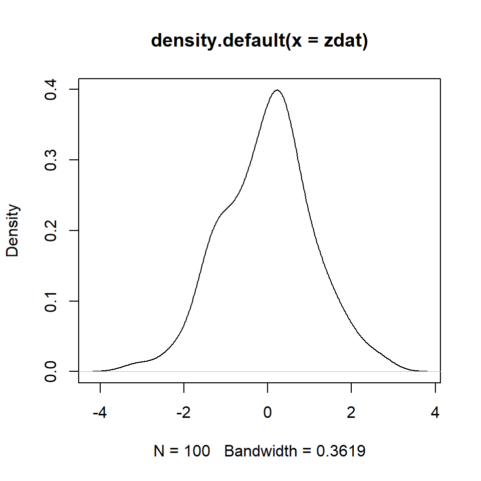

```r
set.seed(111)
zdat <- rnorm(mean=0, sd=1, n=100)
plot(density(zdat))
```

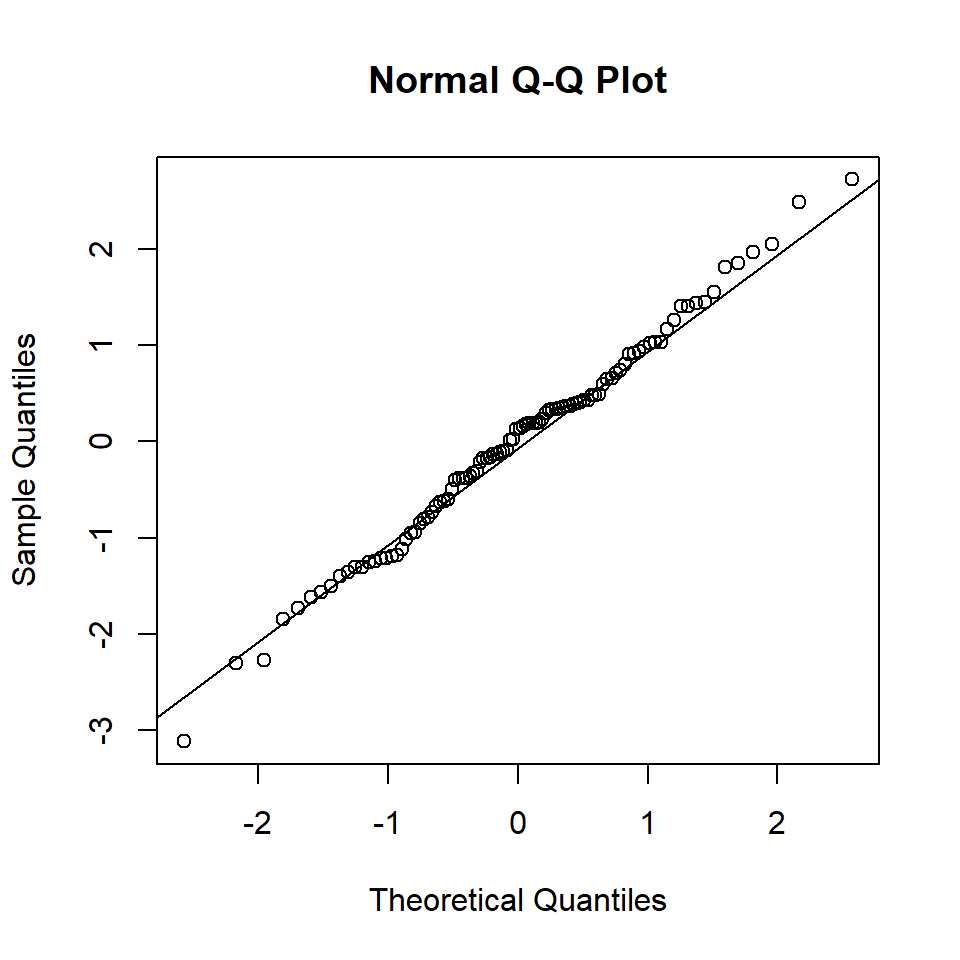

```r
qqnorm(zdat)
qqline(zdat)
```

# 5 Excercise 5

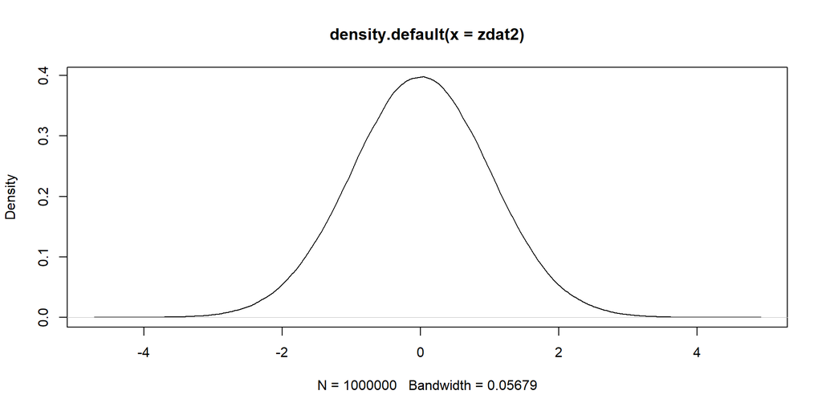

```r
set.seed(111)
zdat2 <- rnorm(mean=0, sd=1, n=1000000)
plot(density(zdat2))
```

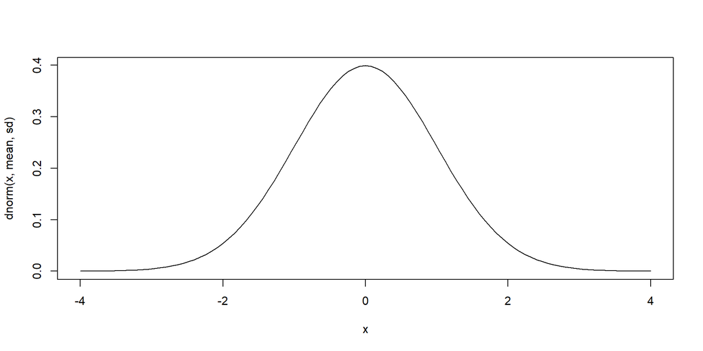

```r
plotNormal <- function(mean=0, sd=1) {
    curve( dnorm(x,mean,sd), xlim=c(mean-4*sd,mean+4*sd) )
}
plotNormal()
```

# 6 Excercise 6

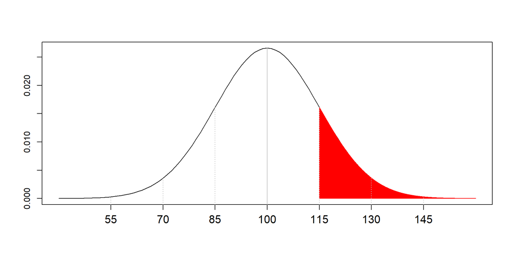

```r
plotNormal <- function(mean=0, sd=1, shademin=NA, shademax=NA, twotailed=F, shadecol='red') {
    # plots normal distribution
    curve(dnorm(x,mean,sd),xlim=c(mean-4*sd,mean+4*sd),xlab='',ylab='',xaxt='n')

    if (!(is.na(shademin) & is.na(shademax))) { # if shademin and/or shademax are set
        # draw shaded area
        if (is.na(shademin)) { shademin <- mean - 4*sd } # shademin if not set is left side of plot
        if (is.na(shademax)) { shademax <- mean + 4*sd } # shademax if not set is right side of plot
        polygon(c(shademin,seq(shademin,shademax,0.01),shademax),
                c(0,dnorm(seq(shademin,shademax,0.01),mean,sd),0),col=shadecol, border=shadecol) # draw area
    }

    # x-axis labels and vertical lines at sd's
    axis(1, at=seq(mean-3*sd,mean+3*sd,by=sd), cex.axis=1.3, labels=round(seq(mean-3*sd,mean+3*sd,by=sd),1))
    for (i in c(-3,-2,-1,0,1,2,3)) {
       segments(mean+i*sd,par("usr")[3],mean+i*sd,dnorm(mean=mean,sd=sd,mean+sd*i),
                lty=ifelse(i==0,1,3),col='gray')
    }
}

plotNormal(mean=100, sd=15, shademin=115)
```

```r
z <- (115-100)/15
pnorm(z, lower.tail=F)
```

```
## [1] 0.1586553
```

```r
pnorm(115, mean=100, sd=15, lower.tail=F)
```

```
## [1] 0.1586553
```

# 7 Excercise 7

```r
se <- 15/sqrt(25)
105 - se*2
```

```
## [1] 99
```

```r
105 + se*2
```

```
## [1] 111
```

```r
105 - (2.6*se)
```

```
## [1] 97.2
```

```r
105 + (2.6*se)
```

```
## [1] 112.8
```

With a 95% certainty we can state that the data from the IQ lies between 99 and 111. From the normal distribution the left and right borders has been calculated. This means we take the dat from 2.5 % to 97.5%

With a 99% certainty we can state that the data from the IQ lies between 97.2 and 112.8. The left and right border from the normal distribution has been calculated above. This means we take the dat from 0.5 % to 99.5%

# 8 Excercise 8

Null-hypothesis: “People in Groningen have a IQ of 100.” Alternative-hypothesis: “People in Groningen have a IQ higher than 100.” H0: mu = 100 Ha: m > 100

I will use a one-sided z-test because I only want to know if it is higher (right side) and not lower (left side). I’ll use the standard error for comparing a sample to the population. If I wanted to know an individual score compared to the population, I would use the standard deviation.

```r
mu <- 100
m <- 105
sd <- 15
sample_pop <- 25
se <- sd/ sqrt(sample_pop)
zscore <- (m - mu)/se
pval <- pnorm(zscore, lower.tail=F)
pval
```

```
## [1] 0.04779035
```

P (z score) < 0,05 and so H0 can be put aside and the alternative hypothesis can be acknowledged. The difference between the means of the IQ are significant.

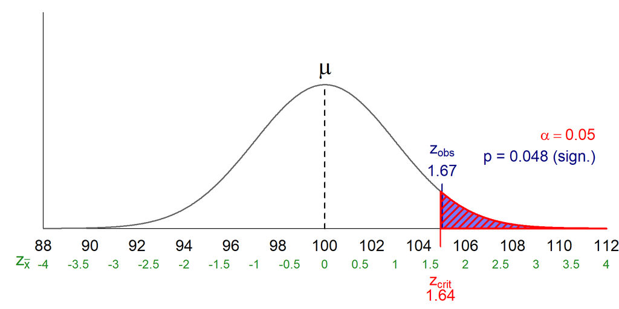

```r
download.file('http://www.let.rug.nl/wieling/Statistiek-I/zvis.R','zvis.R') # downloads file
source('zvis.R') # loads function, so you can use it in R
zvis(m, mu, sd, sample_pop, "right", alpha = 0.05)
```

```r
effectsize <- (m-mu)/sd
effectsize
```

```
## [1] 0.3333333
```

# 9 Exercise 9

Null-hypothesis: “People in Groningen have a IQ of 100.” Alternative-hypothesis: “People in Groningen have a IQ higher or lower than 100.”

H0: mu is 100 Ha: m is not 100

This is a two sided test because it looks at both sides. It checks if it is smaller or the greater than 100.

```r
pval <- pnorm(zscore, lower.tail=FALSE)  # upper tail
p <- pval*2 # two???tailed p???value
p
```

```
## [1] 0.0955807
```

```r
effectsize
```

```
## [1] 0.3333333
```

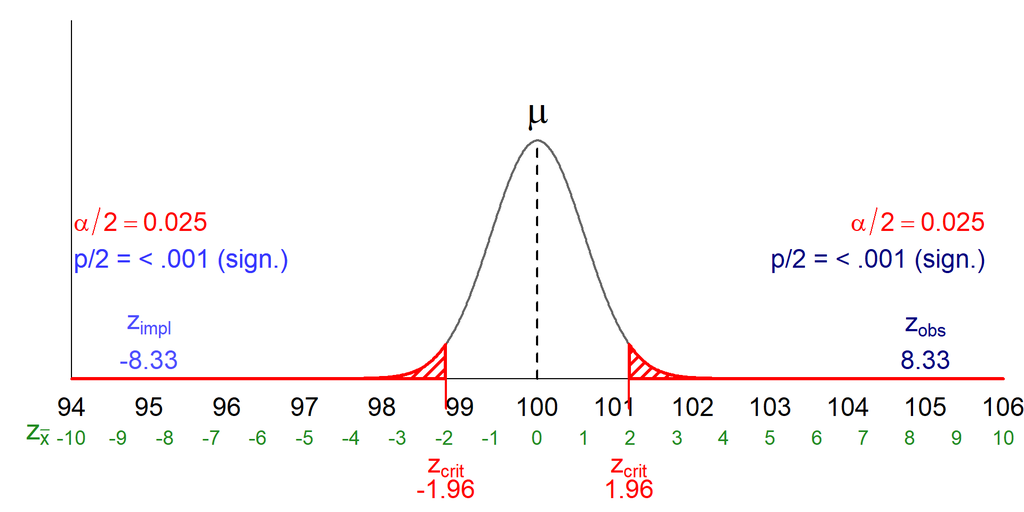

```r
zvis(m, mu, se, sample_pop, "twotailed", alpha = 0.05)
```

# 10 Exercise 10

Null-hypothesis: “People in Groningen speak in a same Dutch proficiency as the general Dutch population.” Alternative-hypothesis: “People in Groningen speak in a worse Dutch proficiency as the general Dutch population.”

H0: mu = 7 H1: mu < 7

This a one sided test because it has been determined that output of the sample has a lower score than the population mean. This means we will look at the mean on the left side.

```r
mu <- 7
sd <- 2
m <- 6.5
sample_pop <- 64
se <- sd/ sqrt(sample_pop)

z <- (mu - m)/se
z
```

```
## [1] 2
```

```r
pval <- pnorm(z, lower.tail = T)
pval
```

```
## [1] 0.9772499
```

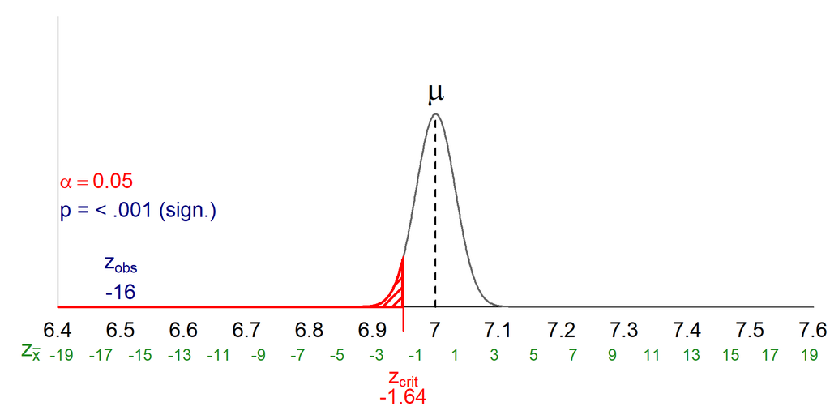

```r
zvis (m, mu, se, sample_pop, "left", alpha = 0.05)
```

# 11 Exercise 11

```r
pnorm(z, lower.tail = T)
```

```
## [1] 0.9772499
```

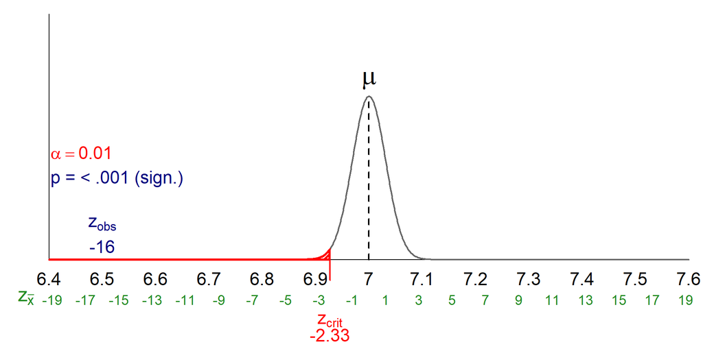

```r
zvis (m, mu, se, sample_pop, "left", alpha= 0.01)
```

```r
effectsize
```

```
## [1] 0.3333333
```